# DATA100 Introduction to Data Analytics

Lecture 3: The Whole Game - Day 2

Agassi Iu

Wilfrid Laurier University

2026-09-17

## Recap: Day 1 of Whole Game

- We examined some EDA (Exploratory Data Analysis): with variables like income, benefits, delayed paycheque difficulty, etc.
- We ended with three financial wellness clusters: Stressed, Coping, Comfortable
- Today: we look at how we actually got there , … including the messy parts of data analytics …

## Before we look at the raw data…

**Thinking Moment**

What do you think could go wrong with real, raw survey data?

**Potential Problems**

What kinds of problems might it have that yesterday’s polished plots didn’t show?

## Here’s the actual raw file

```r
survey_2017_raw <- read_csv("data/raw_survey_2017.csv")

# Note the skip = 1 -- 2022's file has a stray metadata line above the
# real header (a leftover from the export on the new survey platform)
survey_2022_raw <- read_csv("data/raw_survey_2022.csv", skip = 1)

glimpse(survey_2017_raw)
glimpse(survey_2022_raw)
```

## Duplicate responses (rows)

A few respondents show up more than once. - Think of this as a double-submitted survey.

```r
survey_2017_raw |> count(respondent_id, sort = TRUE) |> filter(n > 1)

survey_2017_raw <- survey_2017_raw |> distinct()
survey_2022_raw <- survey_2022_raw |> distinct()
```

The function `distinct()` removes exact duplicate rows. It is always worth checking for *before* doing anything else), since duplicates quietly inflate every count.

## Tidy data: benefits are stuck in wide format

```r
survey_2017_raw |>
  select(respondent_id, starts_with("benefit_")) |>
  head()
```

**Function**

One respondent has a single true preference, but right now it’s scattered across six separate columns. Before we can do anything useful with it, we need to reshape it with `pivot_longer()`.

## Tidy data: `pivot_longer()`

```r
benefits_2017_long <- survey_2017_raw |>
  pivot_longer(
    cols = starts_with("benefit_"),
    names_to = "benefit_type",
    values_to = "response"
  ) |>
  mutate(chosen = response %in% c("Yes", "Y", "yes")) |>
  group_by(respondent_id) |>
  summarize(
    benefit_preference = if (any(chosen)) benefit_type[chosen][1] else NA_character_,
    .groups = "drop"
  )

survey_2017_clean <- survey_2017_raw |>
  select(-starts_with("benefit_")) |>
  left_join(benefits_2017_long, by = "respondent_id")
```

## Strings & expressions

**The format for income response is a mess!**

Sometimes people are allowed to type in their responses however they like. For example, if someone has an annual income of $85,000, there are several ways they might enter that in the survey:

- `"85000"`
- `"$85,000"`
- `"85,000"`
- `"85K"`

So how do we take all these different formats and turn them into something we can actually work with in our analysis?

## Recall from last week’s survey

For Question 7 of the survey, I asked everyone what was the best sandwich?

**Most Popular Answer**

**Grilled Cheese** was among the most popular answers. But this is what I got from last week’s survey response:

- Grilled cheese
- Grilled Cheese
- Grilled Cheese!
- grilled cheese
- grilled cheese with Hot sauce
- Grilled cheese sandwich
- Ham Grilled Cheese

## Back to the Income Example

**Solution**

Before income can be used in any calculation, the income data needs to be transformed into a real number.

```r
clean_income <- function(x) {
  x <- str_trim(x)
  is_k <- str_detect(x, "K$")
  numeric_part <- x |>
    str_remove_all("[$,K]") |>
    as.numeric()
  if_else(is_k, numeric_part * 1000, numeric_part)
}

survey_2017_clean <- survey_2017_clean |>
  mutate(income = clean_income(income))

survey_2022_clean <- survey_2022_clean |>
  mutate(income = clean_income(income))
```

## Strings & expressions: provinces

Same province, several spellings: `"Ontario"`, `"ON"`, `"ontario "`.

```r
standardize_province <- function(x) {
  x <- str_trim(x) |> str_to_lower()
  case_when(
    x %in% c("ontario", "on") ~ "Ontario",
    x %in% c("alberta", "ab") ~ "Alberta",
    x %in% c("british columbia", "bc") ~ "British Columbia",
    x %in% c("quebec", "qc") ~ "Quebec",
    TRUE ~ str_to_title(x)
  )
}

survey_2017_clean <- survey_2017_clean |> mutate(province = standardize_province(province))
survey_2022_clean <- survey_2022_clean |> mutate(province = standardize_province(province))
```

## Strings & expressions: Yes/No

We might get three variations for the same two answers: `"Yes"/"No"`, `"Y"/"N"`, `"yes"/"no"`.

```r
standardize_yn <- function(x) {
  x <- str_trim(x) |> str_to_lower()
  case_when(
    x %in% c("yes", "y") ~ "Yes",
    x %in% c("no", "n") ~ "No",
    TRUE ~ NA_character_
  )
}

survey_2017_clean <- survey_2017_clean |> mutate(debt_overwhelmed = standardize_yn(debt_overwhelmed))
survey_2022_clean <- survey_2022_clean |> mutate(debt_overwhelmed = standardize_yn(debt_overwhelmed))
```

## Missing data

**Where did missing data come from?**

Sometimes we don’t always get all the complete data set that we want.

- People tend to skip questions that they don’t feel comfortable answer.
- perhaps people forgot to fill in one of the questions/pages of survey.
- maybe people gave some weird looking answer that is unusable (e.g $*@2#$1aE&)
- or sometimes these questions are simply irrelevant to them

## Two options: 1) Delete the row

If a respondent didn’t answer a question in the survey, we can just remove this person entirely from the data analysis. :)

**This is cool, but…**

While this is a simple method, you will lose the respondents.

- if the people who skipped the question aren’t random, the ones left behind don’t represent everyone fairly.

```r
survey_2017_nomiss <- survey_2017_clean |>
  drop_na(income, savings_pct,
          debt_overwhelmed,
          emergency_fund_likelihood)
```

## Two options: 2) Imputation

Instead of throwing the whole response away, we can guess a reasonable value to put in its place.

- like using the average of everyone else’s answer. (e.g. mean or median)

```r
survey_2017_clean |> mutate(income = ifelse(is.na(income), median(income, na.rm = TRUE), income))
```

**This is cool, but…**

Now some of your “data” is really just a guess. If you fill in too many values this way, your data can look more similar than it actually is.

## Mismatched response

**Too many response levels**

Sometimes survey designers choose a set of response options one year, then decide to change them the next. For example, in our financial wellness data, the survey asked questions of *How difficult is it to obtain $2,000 of emergency fund?*:

- in 2017, there are 7 levels: *Very difficult*, *Difficult*, *Somewhat difficult*, *Neither*, *Somewhat manageable*, *Manageable*, *Very manageable*
- in 2022, there are now only 5 levels: *Very difficult*, *Difficult*, *Neither*, *Manageable*, *Very manageable*

So what do you do? Neither of them directly match each other. And this is difficult for a year-to-year comparative analysis

## Potential Solution

**Compromise**

We can collapse both down to 3 levels — *Difficult*, *Neither*, *Manageable.*

```r
survey_2017_clean <- survey_2017_clean |>
  mutate(emergency_fund_3lvl = case_when(
    emergency_fund_likelihood %in% c("Very difficult", "Difficult", "Somewhat difficult") ~ "Difficult",
    emergency_fund_likelihood == "Neither" ~ "Neither",
    emergency_fund_likelihood %in% c("Somewhat manageable", "Manageable", "Very manageable") ~ "Manageable",
    TRUE ~ NA_character_
  ))

survey_2022_clean <- survey_2022_clean |>
  mutate(emergency_fund_3lvl = case_when(
    emergency_fund_likelihood %in% c("Very difficult", "Difficult") ~ "Difficult",
    emergency_fund_likelihood == "Neither" ~ "Neither",
    emergency_fund_likelihood %in% c("Manageable", "Very manageable") ~ "Manageable",
    TRUE ~ NA_character_
  ))
```

## Before: 7 Levels vs 5 Levels

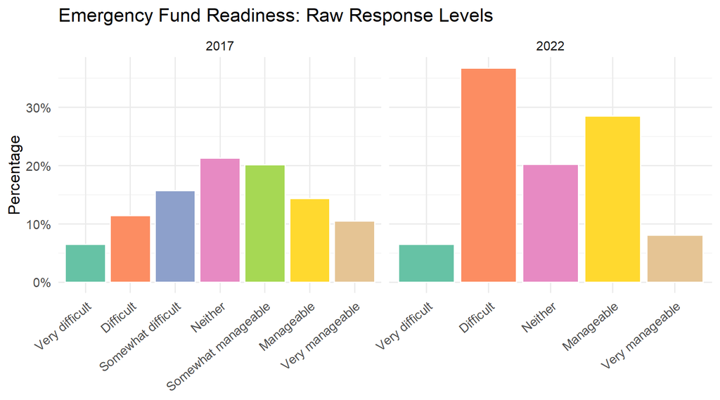

Different number of categories, different wording. It is not easy to tell how people have changed over time by comparing these two bar plots side by side as-is.

## After:

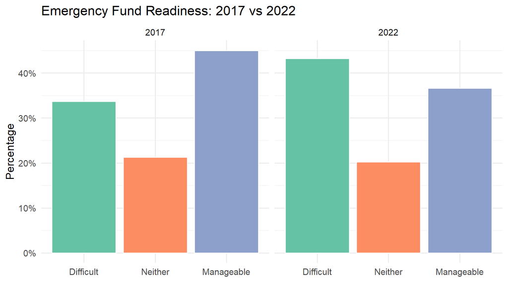

Now that both years use the same 3 levels, we can finally put them side by side and ask: did things get better, worse, or stay the same?

## Different ways of asking the same question

**Mismatched question: same question, different name**

Sometimes a question gets worded differently across years, even though it’s really asking the same thing.

- in 2017, the survey asked *How difficult was it for you if your paycheque is delayed?*
  - stored as `paycheque_delay_difficulty`
- in 2022, the question became *If there is a two week delay in your paycheque arrival, how impactful would it be to your finances?*
  - stored as `twoweek_pay_delay_impact`

## Mismatched responses: Age

```r
survey_2017_clean |> select(age) |> head()
survey_2022_clean |> select(age) |> head()
```

**Are you willing to share your age?**

Sometimes the same underlying question gets *measured* differently across years, even when the intent is identical.

- in 2017, respondents gave an exact age
  - stored as `age`, e.g. `34`
- in 2022, respondents picked from age brackets instead
  - stored as `age`, e.g. `"30-40"`
- Now we have the same underlying question, but a different level of precision
  - In order to compare over the years, everyone needs to speak the same bucket language.

```r
survey_2017_clean <- survey_2017_clean |>
  mutate(age_bucket = case_when(
    age <= 30 ~ "18-30",
    age <= 40 ~ "30-40",
    age <= 50 ~ "40-50",
    age <= 65 ~ "50-65",
    TRUE ~ "65+"
  ))

survey_2022_clean <- survey_2022_clean |>
  rename(age_bucket = age)
```

## Removed benefit option: aligning categories

**Non-existent Option in Survey**

“Educational funding” existed as a choice in 2017, but the 2022 platform dropped it. To compare years fairly, we fold anything not offered in both years into a shared **“Other”** category.

```r
survey_2017_clean <- survey_2017_clean |>
  mutate(benefit_preference = if_else(
    benefit_preference == "benefit_education",
    "benefit_other",
    benefit_preference
  ))
```

## Combine into one data set

```r
survey_combined <- bind_rows(survey_2017_clean, survey_2022_clean)

glimpse(survey_combined)
```

**Only possible now**

Every fix so far existed to make this one line possible.

## Too much info in one column

**One column doing two jobs**

The variable `respondent_id` looks like a single value, but it’s actually smuggling in two separate pieces of information at once.

- the year the response came from, e.g. `2017`
- the respondent’s number within that year, e.g. `0001`

Both are jammed into one string: `"2017-0001"`. If we ever want to work with just the year, or just the respondent number, we’re stuck first pulling them apart.

```r
survey_combined <- survey_combined |>
  separate(respondent_id, into = c("survey_year", "respondent_num"), sep = "-")

survey_combined |>
  select(survey_year, respondent_num, everything()) |>
  head()
```

## Show concluding results

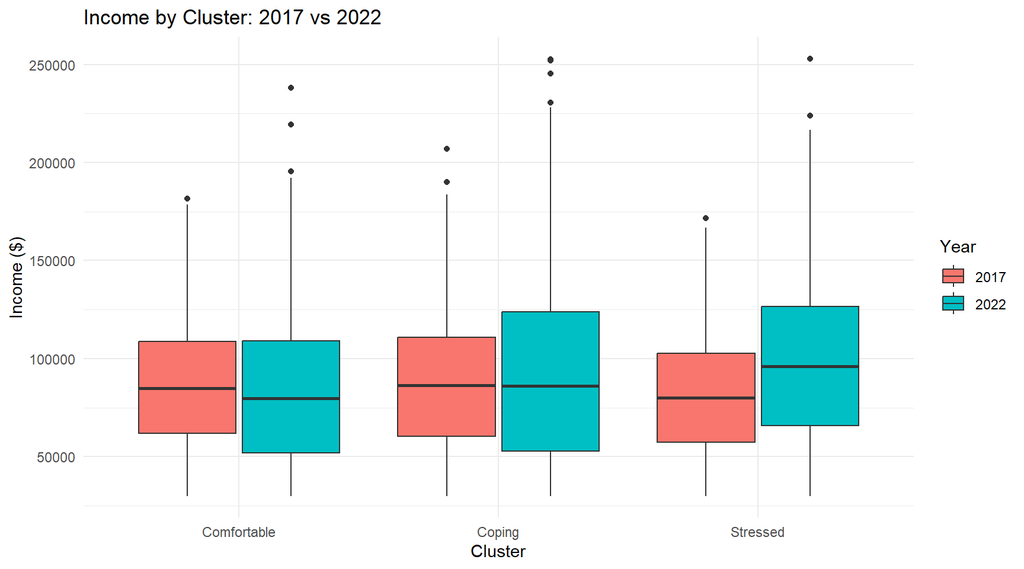

```r
survey_combined |>
  ggplot(aes(x = financial_wellness_cluster, y = income, fill = factor(year))) +
  geom_boxplot(position = position_dodge(width = 0.8)) +
  labs(title = "Income by Cluster: 2017 vs 2022",
       x = "Cluster", y = "Income ($)", fill = "Year") +
  theme_minimal()
```

This is the exact plot style from Day 1, except now you’ve watched every step of how the data underneath it got here.

## Back to your predictions

**Discussion**

Which of your guesses from the start of class came true?

What did we run into that nobody predicted?

**Document your decisions**

A results plot without its cleaning log is a claim without evidence. For any real report, this deserves its own short section (*ahem your final report*):

- Which rows/columns were dropped, and why
- Every recoding decision (e.g. collapsing levels and combining buckets, etc.)
- What’s imputed vs. observed, clearly marked

## A few cautions

**Keep in mind**

- Every cleaning choice was also an analytical choice — a different 3-level collapse, a different age-bucket rule, a different imputation method could all shift what we find downstream
- This dataset is synthetic: today’s numbers are illustrative, not a claim about real Canadians
- Later this semester: missing-data methods and statistical tests that let you make these calls more rigorously than by eyeballing

**Next Week**

We will actually begin learning how to code! Starting with Visualization.